# Proyecto Xiphophorus

Eduardo Cortés

2024-08-29

El proyecto consiste en comparar las diferentes especies del género Xiphophorus en la cuenca del Pánuco. Se utiliza comparación de nichos para estimar la equivalencia de estas especies, y con ayuda de distancias géneticas, se pretende utilizar esta información para responder a la pregunta de si estas especies pueden ser consideradas como una misma entidad filogenética, o si efectivamente las especies presentan suficientes diferencias para ser consideradas por separado

# 1 Descarga de datos de ocurrencias de las especies.

## 1.1 Descarga de datos de la especie *X. birchmanni*

### 1.1.1 Obtenemos y limpiamos los datos

```r
species1<- gbif("Xiphophorus", "birchmanni*", geo=FALSE)
```

```
## 149 records found
```

```
## 0-149 records downloaded
```

```r
data <- subset(species1, !is.na(lon) & !is.na(lat))
dups <- duplicated(data[, c("species", "lon", "lat")])# primer paso para quitar duplicados
dups2<- duplicated(data[, c("lon", "lat")])# segundo paso para quitar duplicados
sum(dups2)# number of duplicates
```

```
## [1] 21
```

```r
data3 <- data[!dups2, ]# keep the records that are _not_ duplicated
data3[,1:13]
```

```
##          acceptedNameUsage                       acceptedScientificName
## 1                     <NA> Xiphophorus birchmanni Lechner & Radda, 1987
## 2                     <NA> Xiphophorus birchmanni Lechner & Radda, 1987
## 3   Xiphophorus birchmanni Xiphophorus birchmanni Lechner & Radda, 1987
## 4                     <NA>                                 BOLD:AAU4073
## 7                     <NA> Xiphophorus birchmanni Lechner & Radda, 1987
## 10  Xiphophorus birchmanni Xiphophorus birchmanni Lechner & Radda, 1987
## 11  Xiphophorus birchmanni Xiphophorus birchmanni Lechner & Radda, 1987
## 12  Xiphophorus birchmanni Xiphophorus birchmanni Lechner & Radda, 1987
## 13  Xiphophorus birchmanni Xiphophorus birchmanni Lechner & Radda, 1987
## 14  Xiphophorus birchmanni Xiphophorus birchmanni Lechner & Radda, 1987
## 15  Xiphophorus birchmanni Xiphophorus birchmanni Lechner & Radda, 1987
## 16  Xiphophorus birchmanni Xiphophorus birchmanni Lechner & Radda, 1987
## 17  Xiphophorus birchmanni Xiphophorus birchmanni Lechner & Radda, 1987
## 18  Xiphophorus birchmanni Xiphophorus birchmanni Lechner & Radda, 1987
```

[output cut: 553 more lines]

```r
data4 <- subset(data3, !is.na(lon) & !is.na(lat))
colnames(data4)
```

```
##   [1] "acceptedNameUsage"             "acceptedScientificName"
##   [3] "acceptedTaxonKey"              "accessRights"
##   [5] "adm1"                          "adm2"
##   [7] "associatedReferences"          "associatedSequences"
##   [9] "basisOfRecord"                 "bibliographicCitation"
##  [11] "catalogNumber"                 "cloc"
##  [13] "collectionCode"                "collectionID"
##  [15] "collectionKey"                 "continent"
##  [17] "coordinateUncertaintyInMeters" "country"
##  [19] "crawlId"                       "datasetID"
##  [21] "datasetKey"                    "datasetName"
##  [23] "dateIdentified"                "day"
##  [25] "depth"                         "depthAccuracy"
##  [27] "disposition"                   "dynamicProperties"
##  [29] "elevation"                     "elevationAccuracy"
```

[output cut: 50 more lines]

```r
write.csv(data4, file = "Xiphophorus_birchmanni_orig.csv") ### para guardar el archivo de puntos
resol <- 0.041665 ### QUITAR LOS DATOS REPETIDOS ESPACIALMENTE en un radio de 5km2
clean_dup <- function(data,longitude,latitude,threshold=0.0){  data <- data[!is.na(data[,longitude]),]
dat_sp <- SpatialPointsDataFrame(data[,c(longitude ,latitude)],data)
dat_sp1 <- remove.duplicates(dat_sp, zero = threshold)
return(dat_sp1@data)}
data5 <- clean_dup(data4,longitude = "lon",latitude = "lat",threshold = resol)### datos espacilamente limpios
```

### 1.1.2 Para armar el archivo .CSV que dara la data de la especie

```r
gbifID<-data5$gbifID
institutionCode<-data5$institutionCode
catalogNumber<-data5$catalogNumber
kingdom<-data5$kingdom
class<-data5$class
order<-data5$order
family<-data5$family
phylum<-data5$phylum
genus<-data5$genus
lat<-data5$lat
species<-data5$species
lon<-data5$lon
year<-data5$year
country<-data5$country
Specie_estudied<-data.frame(gbifID,institutionCode,catalogNumber,kingdom,phylum,order,family,genus,species,lat,lon,year,country)
write.csv(Specie_estudied, file = "Xiphophorus_birchmanni.csv") ### para guardar el archivo de puntos
birchmanni<-data.frame(species, lat, lon)
colnames(birchmanni)<-c("Especie", "Y", "X")
write.csv(birchmanni, file = "X_birchmanni_coords.csv")##guardar coordenadas
```

## 1.2 Descarga de datos de la especie *X. continens*

### 1.2.1 Obtenemos y limpiamos los datos

```r
species1<- gbif("Xiphophorus", "continens*", geo=FALSE)
```

```
## 9 records found
```

```
## 0-9 records downloaded
```

```r
data <- subset(species1, !is.na(lon) & !is.na(lat))
dups <- duplicated(data[, c("species", "lon", "lat")])# primer paso para quitar duplicados
dups2<- duplicated(data[, c("lon", "lat")])# segundo paso para quitar duplicados
sum(dups2)# number of duplicates
```

```
## [1] 0
```

```r
data3 <- data[!dups2, ]# keep the records that are _not_ duplicated
data3[,1:13]
```

```
##       acceptedNameUsage
## 1 Xiphophorus continens
## 3                  <NA>
##                                         acceptedScientificName acceptedTaxonKey
## 1 Xiphophorus continens Rauchenberger, Kallman & Morizot, 1990          2350163
## 3 Xiphophorus continens Rauchenberger, Kallman & Morizot, 1990          2350163
##   accessRights            adm1     adm2      basisOfRecord
## 1         <NA> San luis potosi TAMASOPO PRESERVED_SPECIMEN
## 3         <NA> San Luis Potosi     <NA> PRESERVED_SPECIMEN
##                                                                                                                                                                                                                                                                                                          …
## 1 Soto-Galera, E., L. Alcántara-Soria & J. Paulo-Maya. 2018. Estado actual, identificación de riesgos y propuestas para el manejo de las especies invasoras presentes en las regiones hidrológicas prioritarias, Confluencia de las Huastecas, Media Luna y Cabecera del río de La Laja. Escuela Nacional…
## 3                                                                                                                                                                                                                                                                                                        …
##   catalogNumber
## 1   UMMZ 223207
## 3        223207
##                                                                                                                                              cloc
## 1 Northern branch of Rio Ojo Frio near its nacimiento, N of Damian Carmona, Rio Panuco drainage, San luis potosi, TAMASOPO, Mexico, NORTH_AMERICA
## 3           northern branch of Rio Ojo Frio near its nacimiento, N of Damian Carmona, Rio Panuco drainage, San Luis Potosi, Mexico, NORTH_AMERICA
##   collectionCode collectionID                        collectionKey
## 1           UMMZ         3679 ddfcd903-0d30-4d66-abb1-9a170b877391
## 3      ummz_fish         <NA> 63bd995d-b48c-425d-bb55-04ce8477116d
```

```r
data4 <- subset(data3, !is.na(lon) & !is.na(lat))
colnames(data4)
```

```
##   [1] "acceptedNameUsage"             "acceptedScientificName"
##   [3] "acceptedTaxonKey"              "accessRights"
##   [5] "adm1"                          "adm2"
##   [7] "basisOfRecord"                 "bibliographicCitation"
##   [9] "catalogNumber"                 "cloc"
##  [11] "collectionCode"                "collectionID"
##  [13] "collectionKey"                 "continent"
##  [15] "coordinateUncertaintyInMeters" "country"
##  [17] "crawlId"                       "datasetID"
##  [19] "datasetKey"                    "datasetName"
##  [21] "day"                           "depth"
##  [23] "depthAccuracy"                 "dynamicProperties"
##  [25] "elevation"                     "elevationAccuracy"
##  [27] "endDayOfYear"                  "establishmentMeans"
##  [29] "eventDate"                     "family"
```

[output cut: 41 more lines]

```r
write.csv(data4, file = "Xiphophorus_continens_orig.csv") ### para guardar el archivo de puntos
resol <- 0.041665 ### QUITAR LOS DATOS REPETIDOS ESPACIALMENTE en un radio de 5km2
clean_dup <- function(data,longitude,latitude,threshold=0.0){  data <- data[!is.na(data[,longitude]),]
dat_sp <- SpatialPointsDataFrame(data[,c(longitude ,latitude)],data)
dat_sp1 <- remove.duplicates(dat_sp, zero = threshold)
return(dat_sp1@data)}
data5 <- clean_dup(data4,longitude = "lon",latitude = "lat",threshold = resol)### datos espacilamente limpios
#### Para armar el archivo .CSV que dara la data de la especie
gbifID<-data5$gbifID
institutionCode<-data5$institutionCode
catalogNumber<-data5$catalogNumber
kingdom<-data5$kingdom
class<-data5$class
order<-data5$order
family<-data5$family
phylum<-data5$phylum
genus<-data5$genus
lat<-data5$lat
species<-data5$species
lon<-data5$lon
year<-data5$year
country<-data5$country
Specie_estudied<-data.frame(gbifID,institutionCode,catalogNumber,kingdom,phylum,order,family,genus,species,lat,lon,year,country)
```

### 1.2.2 Para armar el archivo .CSV que dara la data de la especie

```r
gbifID<-data5$gbifID
institutionCode<-data5$institutionCode
catalogNumber<-data5$catalogNumber
kingdom<-data5$kingdom
class<-data5$class
order<-data5$order
family<-data5$family
phylum<-data5$phylum
genus<-data5$genus
lat<-data5$lat
species<-data5$species
lon<-data5$lon
year<-data5$year
country<-data5$country
Specie_estudied<-data.frame(gbifID,institutionCode,catalogNumber,kingdom,phylum,order,family,genus,species,lat,lon,year,country)
write.csv(Specie_estudied, file = "Xiphophorus_continens.csv") ### para guardar el archivo de puntos
continens<-data.frame(species, lat, lon)
colnames(continens)<-c("Especie", "Y", "X")
write.csv(continens, file = "X_continens_coords.csv")##guardar coordenadas
```

## 1.3 Descarga de datos de la especie *X. cortezi*

### 1.3.1 Obtenemos y limpiamos los datos

```r
species1<- gbif("Xiphophorus", "cortezi*", geo=FALSE)
```

```
## 224 records found
```

```
## 0-224 records downloaded
```

```r
data <- subset(species1, !is.na(lon) & !is.na(lat))
dups <- duplicated(data[, c("species", "lon", "lat")])# primer paso para quitar duplicados
dups2<- duplicated(data[, c("lon", "lat")])# segundo paso para quitar duplicados
sum(dups2)# number of duplicates
```

```
## [1] 17
```

```r
data3 <- data[!dups2, ]# keep the records that are _not_ duplicated
data3[,1:13]
```

```
##       acceptedNameUsage          acceptedScientificName acceptedTaxonKey
## 1   Xiphophorus cortezi Xiphophorus cortezi Rosen, 1960          2350180
## 2                  <NA>                    BOLD:AAV7259         10328822
## 4                  <NA> Xiphophorus cortezi Rosen, 1960          2350180
## 6   Xiphophorus cortezi Xiphophorus cortezi Rosen, 1960          2350180
## 7   Xiphophorus cortezi Xiphophorus cortezi Rosen, 1960          2350180
## 8   Xiphophorus cortezi Xiphophorus cortezi Rosen, 1960          2350180
## 9   Xiphophorus cortezi Xiphophorus cortezi Rosen, 1960          2350180
## 10  Xiphophorus cortezi Xiphophorus cortezi Rosen, 1960          2350180
## 11  Xiphophorus cortezi Xiphophorus cortezi Rosen, 1960          2350180
## 12  Xiphophorus cortezi Xiphophorus cortezi Rosen, 1960          2350180
## 13  Xiphophorus cortezi Xiphophorus cortezi Rosen, 1960          2350180
## 15  Xiphophorus cortezi Xiphophorus cortezi Rosen, 1960          2350180
## 16  Xiphophorus cortezi Xiphophorus cortezi Rosen, 1960          2350180
## 17  Xiphophorus cortezi Xiphophorus cortezi Rosen, 1960          2350180
```

[output cut: 425 more lines]

```r
data4 <- subset(data3, !is.na(lon) & !is.na(lat))
colnames(data4)
```

```
##   [1] "acceptedNameUsage"             "acceptedScientificName"
##   [3] "acceptedTaxonKey"              "accessRights"
##   [5] "adm1"                          "adm2"
##   [7] "associatedReferences"          "associatedSequences"
##   [9] "basisOfRecord"                 "bibliographicCitation"
##  [11] "catalogNumber"                 "cloc"
##  [13] "collectionCode"                "collectionID"
##  [15] "collectionKey"                 "continent"
##  [17] "coordinateUncertaintyInMeters" "country"
##  [19] "crawlId"                       "datasetID"
##  [21] "datasetKey"                    "datasetName"
##  [23] "dateIdentified"                "day"
##  [25] "depth"                         "depthAccuracy"
##  [27] "disposition"                   "dynamicProperties"
##  [29] "elevation"                     "elevationAccuracy"
```

[output cut: 49 more lines]

```r
write.csv(data4, file = "Xiphophorus_cortezi_orig.csv") ### para guardar el archivo de puntos
resol <- 0.041665 ### QUITAR LOS DATOS REPETIDOS ESPACIALMENTE en un radio de 5km2
clean_dup <- function(data,longitude,latitude,threshold=0.0){  data <- data[!is.na(data[,longitude]),]
dat_sp <- SpatialPointsDataFrame(data[,c(longitude ,latitude)],data)
dat_sp1 <- remove.duplicates(dat_sp, zero = threshold)
return(dat_sp1@data)}
data5 <- clean_dup(data4,longitude = "lon",latitude = "lat",threshold = resol) ### datos espacilamente limpios
```

### 1.3.2 Para armar el archivo .CSV que dara la data de la especie

```r
gbifID<-data5$gbifID
institutionCode<-data5$institutionCode
catalogNumber<-data5$catalogNumber
kingdom<-data5$kingdom
phylum<-data5$phylum
order<-data5$order
family<-data5$family
genus<-data5$genus
species<-data5$species
lat<-data5$lat
lon<-data5$lon
year<-data5$year
country<-data5$country
Specie_estudied<-data.frame(gbifID,institutionCode,catalogNumber,kingdom,phylum,order,family,genus,species,lat,lon,year,country)
write.csv(Specie_estudied, file = "Xiphophorus_cortezi.csv") ### para guardar el archivo de datos
cortezi<-data.frame(species, lat, lon)
colnames(cortezi)<-c("Especie", "Y", "X")
write.csv(cortezi, file = "X_cortezi_coords.csv")##guardar coordenadas
```

## 1.4 Descarga de datos de la especie *X. malinche*

### 1.4.1 Obtenemos y limpiamos los datos

```r
species1<- gbif("Xiphophorus", "malinche*", geo=FALSE)
```

```
## 51 records found
```

```
## 0-51 records downloaded
```

```r
data <- subset(species1, !is.na(lon) & !is.na(lat))
dups <- duplicated(data[, c("species", "lon", "lat")])# primer paso para quitar duplicados
dups2<- duplicated(data[, c("lon", "lat")])# segundo paso para quitar duplicados
sum(dups2)# number of duplicates
```

```
## [1] 9
```

```r
data3 <- data[!dups2, ]# keep the records that are _not_ duplicated
data3[,1:13]
```

```
##       acceptedNameUsage
## 1                  <NA>
## 2                  <NA>
## 3  Xiphophorus malinche
## 5  Xiphophorus malinche
## 9  Xiphophorus malinche
## 11 Xiphophorus malinche
## 12 Xiphophorus malinche
## 16 Xiphophorus malinche
## 17 Xiphophorus malinche
## 18 Xiphophorus malinche
## 19 Xiphophorus malinche
## 20 Xiphophorus malinche
## 21 Xiphophorus malinche
## 22 Xiphophorus malinche
```

[output cut: 264 more lines]

```r
data4 <- subset(data3, !is.na(lon) & !is.na(lat))
colnames(data4)
```

```
##   [1] "acceptedNameUsage"             "acceptedScientificName"
##   [3] "acceptedTaxonKey"              "accessRights"
##   [5] "adm1"                          "adm2"
##   [7] "associatedReferences"          "basisOfRecord"
##   [9] "bibliographicCitation"         "catalogNumber"
##  [11] "cloc"                          "collectionCode"
##  [13] "collectionID"                  "collectionKey"
##  [15] "continent"                     "coordinateUncertaintyInMeters"
##  [17] "country"                       "crawlId"
##  [19] "datasetID"                     "datasetKey"
##  [21] "datasetName"                   "dateIdentified"
##  [23] "day"                           "depth"
##  [25] "depthAccuracy"                 "disposition"
##  [27] "dynamicProperties"             "elevation"
##  [29] "elevationAccuracy"             "endDayOfYear"
```

[output cut: 46 more lines]

```r
write.csv(data4, file = "Xiphophorus_malinche_orig.csv") ### para guardar el archivo de puntos
resol <- 0.041665 ### QUITAR LOS DATOS REPETIDOS ESPACIALMENTE en un radio de 5km2
clean_dup <- function(data,longitude,latitude,threshold=0.0){  data <- data[!is.na(data[,longitude]),]
dat_sp <- SpatialPointsDataFrame(data[,c(longitude ,latitude)],data)
dat_sp1 <- remove.duplicates(dat_sp, zero = threshold)
return(dat_sp1@data)}
data5 <- clean_dup(data4,longitude = "lon",latitude = "lat",threshold = resol)### datos espacilamente limpios
```

### 1.4.2 Para armar el archivo .CSV que dara la data de la especie

```r
gbifID<-data5$gbifID
institutionCode<-data5$institutionCode
catalogNumber<-data5$catalogNumber
kingdom<-data5$kingdom
class<-data5$class
order<-data5$order
family<-data5$family
phylum<-data5$phylum
genus<-data5$genus
lat<-data5$lat
species<-data5$species
lon<-data5$lon
year<-data5$year
country<-data5$country
Specie_estudied<-data.frame(gbifID,institutionCode,catalogNumber,kingdom,phylum,order,family,genus,species,lat,lon,year,country)
write.csv(Specie_estudied, file = "Xiphophorus_malinche.csv") ### para guardar el archivo de puntos
malinche<-data.frame(species, lat, lon)
colnames(malinche)<-c("Especie", "Y", "X")
write.csv(malinche, file = "X_malinche_coords.csv")##guardar coordenadas
```

## 1.5 Descarga de datos de la especie *X. multilineatus*

### 1.5.1 Obtenemos y limpiamos los datos

```r
species1<- gbif("Xiphophorus", "multilineatus*", geo=FALSE)
```

```
## 43 records found
```

```
## 0-43 records downloaded
```

```r
data <- subset(species1, !is.na(lon) & !is.na(lat))
dups <- duplicated(data[, c("species", "lon", "lat")])# primer paso para quitar duplicados
dups2<- duplicated(data[, c("lon", "lat")])# segundo paso para quitar duplicados
sum(dups2)# number of duplicates
```

```
## [1] 11
```

```r
data3 <- data[!dups2, ]# keep the records that are _not_ duplicated
data3[,1:13]
```

```
##            acceptedNameUsage
## 2                       <NA>
## 3                       <NA>
## 5  Xiphophorus multilineatus
## 6                       <NA>
## 20 Xiphophorus multilineatus
## 21 Xiphophorus multilineatus
## 22 Xiphophorus multilineatus
## 23 Xiphophorus multilineatus
## 24 Xiphophorus multilineatus
## 25 Xiphophorus multilineatus
## 26 Xiphophorus multilineatus
##                                              acceptedScientificName
## 2  Xiphophorus multilineatus Rauchenberger, Kallman & Morizot, 1990
## 3  Xiphophorus multilineatus Rauchenberger, Kallman & Morizot, 1990
```

[output cut: 93 more lines]

```r
data4 <- subset(data3, !is.na(lon) & !is.na(lat))
colnames(data4)
```

```
##   [1] "acceptedNameUsage"             "acceptedScientificName"
##   [3] "acceptedTaxonKey"              "accessRights"
##   [5] "adm1"                          "adm2"
##   [7] "associatedReferences"          "basisOfRecord"
##   [9] "bibliographicCitation"         "catalogNumber"
##  [11] "cloc"                          "collectionCode"
##  [13] "collectionID"                  "collectionKey"
##  [15] "continent"                     "coordinatePrecision"
##  [17] "coordinateUncertaintyInMeters" "country"
##  [19] "crawlId"                       "datasetID"
##  [21] "datasetKey"                    "datasetName"
##  [23] "day"                           "depth"
##  [25] "depthAccuracy"                 "dynamicProperties"
##  [27] "elevation"                     "elevationAccuracy"
##  [29] "endDayOfYear"                  "establishmentMeans"
```

[output cut: 44 more lines]

```r
write.csv(data4, file = "Xiphophorus_multilineatus_orig.csv") ### para guardar el archivo de puntos
resol <- 0.041665 ### QUITAR LOS DATOS REPETIDOS ESPACIALMENTE en un radio de 5km2
clean_dup <- function(data,longitude,latitude,threshold=0.0){  data <- data[!is.na(data[,longitude]),]
dat_sp <- SpatialPointsDataFrame(data[,c(longitude ,latitude)],data)
dat_sp1 <- remove.duplicates(dat_sp, zero = threshold)
return(dat_sp1@data)}
data5 <- clean_dup(data4,longitude = "lon",latitude = "lat",threshold = resol)### datos espacilamente limpios
```

### 1.5.2 Para armar el archivo .CSV que dara la data de la especie

```r
gbifID<-data5$gbifID
institutionCode<-data5$institutionCode
catalogNumber<-data5$catalogNumber
kingdom<-data5$kingdom
class<-data5$class
order<-data5$order
family<-data5$family
phylum<-data5$phylum
genus<-data5$genus
lat<-data5$lat
species<-data5$species
lon<-data5$lon
year<-data5$year
country<-data5$country
Specie_estudied<-data.frame(gbifID,institutionCode,catalogNumber,kingdom,phylum,order,family,genus,species,lat,lon,year,country)
write.csv(Specie_estudied, file = "Xiphophorus_multilineatus.csv") ### para guardar el archivo de puntos
multilineatus<-data.frame(species, lat, lon)
colnames(multilineatus)<-c("Especie", "Y", "X")
write.csv(multilineatus, file = "X_multilineatus_coords.csv")##guardar coordenadas
```

## 1.6 Descarga de datos de la especie *X. nezahualcoyotl*

### 1.6.1 Obtenemos y limpiamos los datos

```r
species1<- gbif("Xiphophorus", "nezahualcoyotl*", geo=FALSE)
```

```
## 57 records found
```

```
## 0-57 records downloaded
```

```r
data <- subset(species1, !is.na(lon) & !is.na(lat))
dups <- duplicated(data[, c("species", "lon", "lat")])# primer paso para quitar duplicados
dups2<- duplicated(data[, c("lon", "lat")])# segundo paso para quitar duplicados
sum(dups2)# number of duplicates
```

```
## [1] 25
```

```r
data3 <- data[!dups2, ]# keep the records that are _not_ duplicated
data3[,1:13]
```

```
##             acceptedNameUsage
## 1                        <NA>
## 2  Xiphophorus nezahualcoyotl
## 3                        <NA>
## 7                        <NA>
## 8                        <NA>
## 9                        <NA>
## 11 Xiphophorus nezahualcoyotl
## 12 Xiphophorus nezahualcoyotl
## 33 Xiphophorus nezahualcoyotl
## 44                       <NA>
## 45                       <NA>
## 53                       <NA>
##                                               acceptedScientificName
## 1  Xiphophorus nezahualcoyotl Rauchenberger, Kallman & Morizot, 1990
```

[output cut: 115 more lines]

```r
data4 <- subset(data3, !is.na(lon) & !is.na(lat))
colnames(data4)
```

```
##   [1] "acceptedNameUsage"              "acceptedScientificName"
##   [3] "acceptedTaxonKey"               "accessRights"
##   [5] "adm1"                           "adm2"
##   [7] "associatedReferences"           "associatedSequences"
##   [9] "basisOfRecord"                  "bibliographicCitation"
##  [11] "catalogNumber"                  "cloc"
##  [13] "collectionCode"                 "collectionID"
##  [15] "collectionKey"                  "continent"
##  [17] "coordinateUncertaintyInMeters"  "country"
##  [19] "crawlId"                        "datasetID"
##  [21] "datasetKey"                     "datasetName"
##  [23] "dateIdentified"                 "day"
##  [25] "depth"                          "depthAccuracy"
##  [27] "disposition"                    "dynamicProperties"
##  [29] "elevation"                      "elevationAccuracy"
```

[output cut: 47 more lines]

```r
write.csv(data4, file = "Xiphophorus_nezahualcoyotl_orig.csv") ### para guardar el archivo de puntos
resol <- 0.041665 ### QUITAR LOS DATOS REPETIDOS ESPACIALMENTE en un radio de 5km2
clean_dup <- function(data,longitude,latitude,threshold=0.0){  data <- data[!is.na(data[,longitude]),]
dat_sp <- SpatialPointsDataFrame(data[,c(longitude ,latitude)],data)
dat_sp1 <- remove.duplicates(dat_sp, zero = threshold)
return(dat_sp1@data)}
data5 <- clean_dup(data4,longitude = "lon",latitude = "lat",threshold = resol)### datos espacilamente limpios
```

### 1.6.2 Para armar el archivo .CSV que dara la data de la especie

```r
gbifID<-data5$gbifID
institutionCode<-data5$institutionCode
catalogNumber<-data5$catalogNumber
kingdom<-data5$kingdom
phylum<-data5$phylum
class<-data5$class
family<-data5$family
order<-data5$order
genus<-data5$genus
species<-data5$species
lat<-data5$lat
lon<-data5$lon
year<-data5$year
country<-data5$country
Specie_estudied<-data.frame(gbifID,institutionCode,catalogNumber,kingdom,phylum,order,family,genus,species,lat,lon,year,country)
write.csv(Specie_estudied, file = "Xiphophorus_nezahualcoyotl.csv") ### para guardar el archivo de puntos
neza<-data.frame(species, lat, lon)
colnames(neza)<-c("Especie", "Y", "X")
write.csv(neza, file = "X_nezahualcoyotl_coords.csv")##guardar coordenadas
```

## 1.7 Descarga de datos de la especie *X. nigrensis*

### 1.7.1 Obtenemos y limpiamos los datos

```r
species1<- gbif("Xiphophorus", "nigrensis*", geo=FALSE)
```

```
## 129 records found
```

```
## 0-129 records downloaded
```

```r
data <- subset(species1, !is.na(lon) & !is.na(lat))
dups <- duplicated(data[, c("species", "lon", "lat")])# primer paso para quitar duplicados
dups2<- duplicated(data[, c("lon", "lat")])# segundo paso para quitar duplicados
sum(dups2)# number of duplicates
```

```
## [1] 25
```

```r
data3 <- data[!dups2, ]# keep the records that are _not_ duplicated
data3[,1:13]
```

```
##        acceptedNameUsage            acceptedScientificName acceptedTaxonKey
## 1  Xiphophorus nigrensis Xiphophorus nigrensis Rosen, 1960          2350157
## 2                   <NA> Xiphophorus nigrensis Rosen, 1960          2350157
## 3                   <NA> Xiphophorus nigrensis Rosen, 1960          2350157
## 4                   <NA> Xiphophorus nigrensis Rosen, 1960          2350157
## 5                   <NA> Xiphophorus nigrensis Rosen, 1960          2350157
## 7                   <NA> Xiphophorus nigrensis Rosen, 1960          2350157
## 8  Xiphophorus nigrensis Xiphophorus nigrensis Rosen, 1960          2350157
## 49                  <NA> Xiphophorus nigrensis Rosen, 1960          2350157
## 52 Xiphophorus nigrensis Xiphophorus nigrensis Rosen, 1960          2350157
## 54                  <NA> Xiphophorus nigrensis Rosen, 1960          2350157
##               adm1          adm2
## 1  San luis potosi CIUDAD VALLES
## 2  San Luis Potosi      Tanlajas
## 3  San Luis Potosi Ciudad Valles
```

[output cut: 73 more lines]

```r
data4 <- subset(data3, !is.na(lon) & !is.na(lat))
colnames(data4)
```

```
##   [1] "acceptedNameUsage"             "acceptedScientificName"
##   [3] "acceptedTaxonKey"              "adm1"
##   [5] "adm2"                          "associatedReferences"
##   [7] "basisOfRecord"                 "bibliographicCitation"
##   [9] "catalogNumber"                 "cloc"
##  [11] "collectionCode"                "collectionID"
##  [13] "collectionKey"                 "continent"
##  [15] "coordinatePrecision"           "coordinateUncertaintyInMeters"
##  [17] "country"                       "crawlId"
##  [19] "datasetID"                     "datasetKey"
##  [21] "datasetName"                   "day"
##  [23] "depth"                         "depthAccuracy"
##  [25] "dynamicProperties"             "elevation"
##  [27] "elevationAccuracy"             "endDayOfYear"
##  [29] "eventDate"                     "eventRemarks"
```

[output cut: 44 more lines]

```r
write.csv(data4, file = "Xiphophorus_nigrensis_orig.csv") ### para guardar el archivo de puntos
resol <- 0.041665 ### QUITAR LOS DATOS REPETIDOS ESPACIALMENTE en un radio de 5km2
clean_dup <- function(data,longitude,latitude,threshold=0.0){  data <- data[!is.na(data[,longitude]),]
dat_sp <- SpatialPointsDataFrame(data[,c(longitude ,latitude)],data)
dat_sp1 <- remove.duplicates(dat_sp, zero = threshold)
return(dat_sp1@data)}
data5 <- clean_dup(data4,longitude = "lon",latitude = "lat",threshold = resol)### datos espacilamente limpios
```

### 1.7.2 Para armar el archivo .CSV que dara la data de la especie

```r
gbifID<-data5$gbifID
institutionCode<-data5$institutionCode
catalogNumber<-data5$catalogNumber
kingdom<-data5$kingdom
class<-data5$class
order<-data5$order
family<-data5$family
phylum<-data5$phylum
genus<-data5$genus
lat<-data5$lat
species<-data5$species
lon<-data5$lon
year<-data5$year
country<-data5$country
Specie_estudied<-data.frame(gbifID,institutionCode,catalogNumber,kingdom,phylum,order,family,genus,species,lat,lon,year,country)
write.csv(Specie_estudied, file = "Xiphophorus_nigrensis.csv") ### para guardar el archivo de puntos
nigrensis<-data.frame(species, lat, lon)
colnames(nigrensis)<-c("Especie", "Y", "X")
write.csv(nigrensis, file = "X_nigrensis_coords.csv")##guardar coordenadas
```

## 1.8 Descarga de datos de la especie *X. pygmaeus*

### 1.8.1 Obtenemos y limpiamos los datos

```r
species1<- gbif("Xiphophorus", "pygmaeus*", geo=FALSE)
```

```
## 216 records found
```

```
## 0-216 records downloaded
```

```r
data <- subset(species1, !is.na(lon) & !is.na(lat))
dups <- duplicated(data[, c("species", "lon", "lat")])# primer paso para quitar duplicados
dups2<- duplicated(data[, c("lon", "lat")])# segundo paso para quitar duplicados
sum(dups2)# number of duplicates
```

```
## [1] 56
```

```r
data3 <- data[!dups2, ]# keep the records that are _not_ duplicated
data3[,1:13]
```

```
##        acceptedNameUsage                    acceptedScientificName
## 1   Xiphophorus pygmaeus Xiphophorus pygmaeus Hubbs & Gordon, 1943
## 2                   <NA>                              BOLD:AAV7258
## 4                   <NA> Xiphophorus pygmaeus Hubbs & Gordon, 1943
## 6   Xiphophorus pygmaeus Xiphophorus pygmaeus Hubbs & Gordon, 1943
## 7                   <NA> Xiphophorus pygmaeus Hubbs & Gordon, 1943
## 8   Xiphophorus pygmaeus Xiphophorus pygmaeus Hubbs & Gordon, 1943
## 9   Xiphophorus pygmaeus Xiphophorus pygmaeus Hubbs & Gordon, 1943
## 10  Xiphophorus pygmaeus Xiphophorus pygmaeus Hubbs & Gordon, 1943
## 11  Xiphophorus pygmaeus Xiphophorus pygmaeus Hubbs & Gordon, 1943
## 12                  <NA> Xiphophorus pygmaeus Hubbs & Gordon, 1943
## 33                  <NA> Xiphophorus pygmaeus Hubbs & Gordon, 1943
## 36                  <NA> Xiphophorus pygmaeus Hubbs & Gordon, 1943
## 37                  <NA> Xiphophorus pygmaeus Hubbs & Gordon, 1943
## 44                  <NA> Xiphophorus pygmaeus Hubbs & Gordon, 1943
```

[output cut: 372 more lines]

```r
data4 <- subset(data3, !is.na(lon) & !is.na(lat))
colnames(data4)
```

```
##   [1] "acceptedNameUsage"              "acceptedScientificName"
##   [3] "acceptedTaxonKey"               "accessRights"
##   [5] "adm1"                           "adm2"
##   [7] "associatedReferences"           "associatedSequences"
##   [9] "basisOfRecord"                  "bibliographicCitation"
##  [11] "catalogNumber"                  "cloc"
##  [13] "collectionCode"                 "collectionID"
##  [15] "collectionKey"                  "continent"
##  [17] "coordinatePrecision"            "coordinateUncertaintyInMeters"
##  [19] "country"                        "crawlId"
##  [21] "datasetID"                      "datasetKey"
##  [23] "datasetName"                    "dateIdentified"
##  [25] "day"                            "depth"
##  [27] "depthAccuracy"                  "disposition"
##  [29] "dynamicProperties"              "elevation"
```

[output cut: 52 more lines]

```r
write.csv(data4, file = "Xiphophorus_pygmaeus_orig.csv") ### para guardar el archivo de puntos
resol <- 0.041665 ### QUITAR LOS DATOS REPETIDOS ESPACIALMENTE en un radio de 5km2
clean_dup <- function(data,longitude,latitude,threshold=0.0){  data <- data[!is.na(data[,longitude]),]
dat_sp <- SpatialPointsDataFrame(data[,c(longitude ,latitude)],data)
dat_sp1 <- remove.duplicates(dat_sp, zero = threshold)
return(dat_sp1@data)}
#Datos espacilamente limpios
data5 <- clean_dup(data4,longitude = "lon",latitude = "lat",threshold = resol)
```

### 1.8.2 Para armar el archivo .CSV que dara la data de la especie

```r
gbifID<-data5$gbifID
institutionCode<-data5$institutionCode
catalogNumber<-data5$catalogNumber
kingdom<-data5$kingdom
class<-data5$class
order<-data5$order
family<-data5$family
phylum<-data5$phylum
genus<-data5$genus
lat<-data5$lat
species<-data5$species
lon<-data5$lon
year<-data5$year
country<-data5$country
Specie_estudied<-data.frame(gbifID,institutionCode,catalogNumber,kingdom,phylum,order,family,genus,species,lat,lon,year,country)

write.csv(Specie_estudied, file = "Xiphophorus_pygmaeus.csv")
pygmaeus<-data.frame(species, lat, lon)
colnames(pygmaeus)<-c("Especie", "Y", "X")
write.csv(pygmaeus, file = "X_pygmaeus_coords.csv")
```

## 1.9 Descarga de datos de la especie *X. variatus*

### 1.9.1 Obtenemos y limpiamos los datos

```r
species1<- gbif("Xiphophorus", "variatus*", geo=FALSE)
```

```
## 1009 records found
```

```
## 0-300-600-900-1009 records downloaded
```

```r
data <- subset(species1, !is.na(lon) & !is.na(lat))
dups <- duplicated(data[, c("species", "lon", "lat")])# primer paso para quitar duplicados
dups2<- duplicated(data[, c("lon", "lat")])# segundo paso para quitar duplicados
sum(dups2)# number of duplicates
```

```
## [1] 275
```

```r
data3 <- data[!dups2, ]# keep the records that are _not_ duplicated
data3[,1:13]
```

```
##         acceptedNameUsage                        acceptedNameUsageID
## 1                    <NA>                                       <NA>
## 2                    <NA>                                       <NA>
## 3                    <NA>                                       <NA>
## 4                    <NA>                                       <NA>
## 5                    <NA>                                       <NA>
## 6                    <NA>                                       <NA>
## 7                    <NA>                                       <NA>
## 8                    <NA>                                       <NA>
## 9                    <NA>                                       <NA>
## 10                   <NA>                                       <NA>
## 11                   <NA>                                       <NA>
## 12                   <NA>                                       <NA>
## 13                   <NA>                                       <NA>
## 14                   <NA>                                       <NA>
```

[output cut: 4585 more lines]

```r
data4 <- subset(data3, !is.na(lon) & !is.na(lat))
colnames(data4)
```

```
##   [1] "acceptedNameUsage"                  "acceptedNameUsageID"
##   [3] "acceptedScientificName"             "acceptedTaxonKey"
##   [5] "accessRights"                       "adm1"
##   [7] "adm2"                               "associatedReferences"
##   [9] "associatedSequences"                "basisOfRecord"
##  [11] "bibliographicCitation"              "catalogNumber"
##  [13] "cloc"                               "collectionCode"
##  [15] "collectionID"                       "collectionKey"
##  [17] "continent"                          "coordinatePrecision"
##  [19] "coordinateUncertaintyInMeters"      "country"
##  [21] "crawlId"                            "datasetID"
##  [23] "datasetKey"                         "datasetName"
##  [25] "dateIdentified"                     "day"
##  [27] "depth"                              "depthAccuracy"
##  [29] "disposition"                        "distanceFromCentroidInMeters"
```

[output cut: 62 more lines]

```r
write.csv(data4, file = "Xiphophorus_variatus_orig.csv") ### para guardar el archivo de puntos
resol <- 0.041665 ### QUITAR LOS DATOS REPETIDOS ESPACIALMENTE en un radio de 5km2
clean_dup <- function(data,longitude,latitude,threshold=0.0){  data <- data[!is.na(data[,longitude]),]
dat_sp <- SpatialPointsDataFrame(data[,c(longitude ,latitude)],data)
dat_sp1 <- remove.duplicates(dat_sp, zero = threshold)
return(dat_sp1@data)}
data5 <- clean_dup(data4,longitude = "lon",latitude = "lat",threshold = resol)### datos espacilamente limpios
```

### 1.9.2 Para armar el archivo .CSV que dara la data de la especie

```r
gbifID<-data5$gbifID
institutionCode<-data5$institutionCode
catalogNumber<-data5$catalogNumber
kingdom<-data5$kingdom
class<-data5$class
order<-data5$order
family<-data5$family
phylum<-data5$phylum
genus<-data5$genus
lat<-data5$lat
species<-data5$species
lon<-data5$lon
year<-data5$year
country<-data5$country
Specie_estudied<-data.frame(gbifID,institutionCode,catalogNumber,kingdom,phylum,order,family,genus,species,lat,lon,year,country)
write.csv(Specie_estudied, file = "Xiphophorus_variatus.csv") ### para guardar el archivo de puntos
variatus<-data.frame(species, lat, lon)
colnames(variatus)<-c("Especie", "Y", "X")
write.csv(variatus, file = "X_variatus_coords.csv")##guardar coordenadas
```

# 2 Creación de las capas que usaremos para delimitar el área de estudio.

## 2.1 Obtención de las capas climáticas.

```r
geodata_path(getwd())
country_codes(query = "Mex")
```

```
##       NAME ISO3 ISO2 NAME_ISO NAME_FAO                      NAME_LOCAL
## 145 Mexico  MEX   MX   MEXICO   Mexico México|Estados Unidos Mexicanos
##     SOVEREIGN       UNREGION1 UNREGION2     continent
## 145    México Central America  Americas North America
```

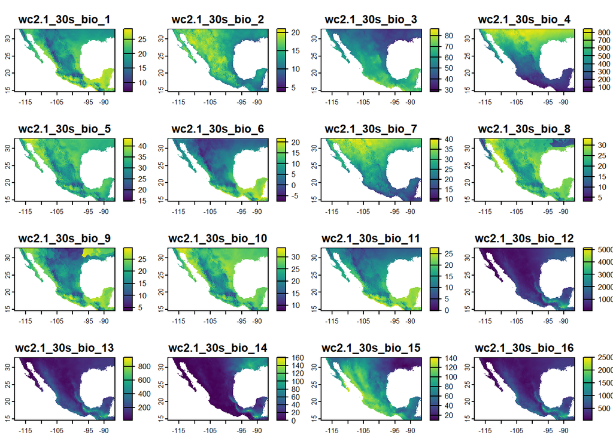

```r
bioclimvar <- geodata::worldclim_country("MEXICO", var = "bio", res = 0.00833333279799999, download = F)
plot(bioclimvar)
```

## 2.2 Cortamos las capas obtenidas.

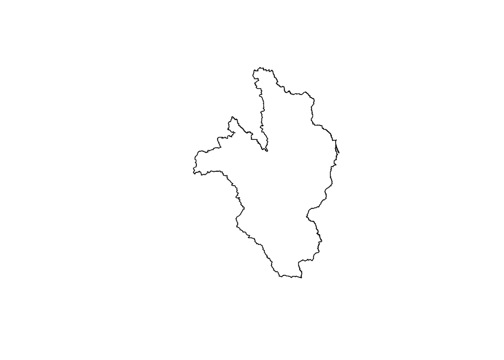

```r
mascara<-shapefile("Panuco.shp")
plot(mascara) #asegurarse que sea cargada correctamente
```

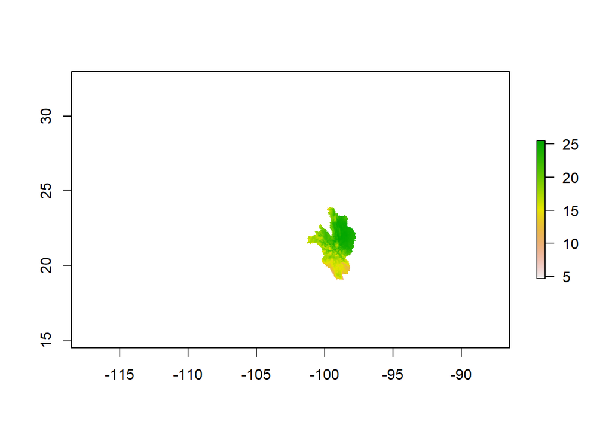

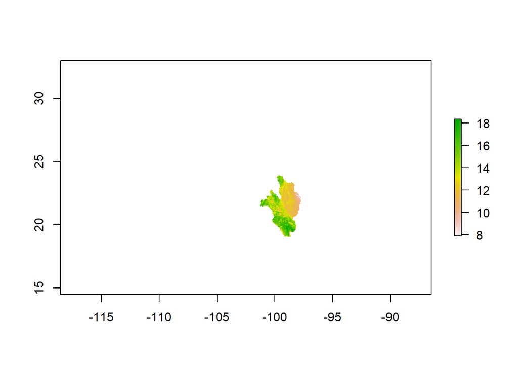

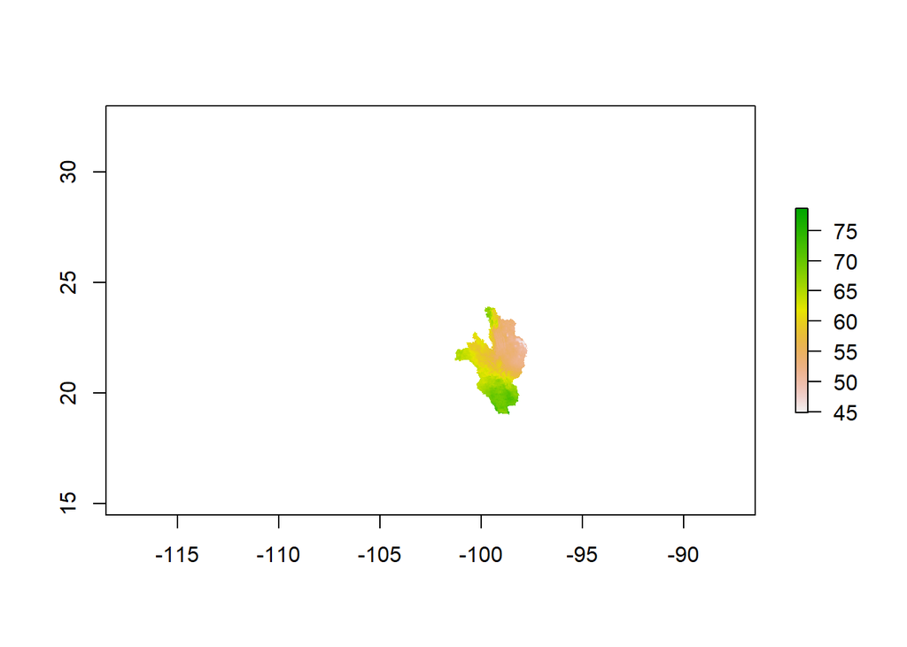

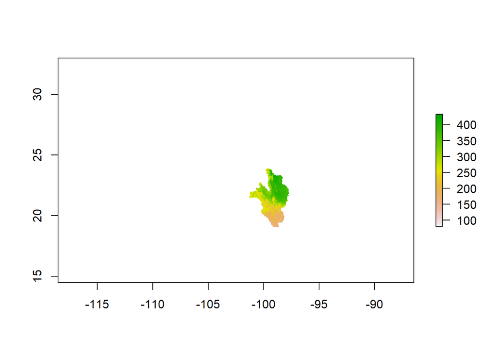

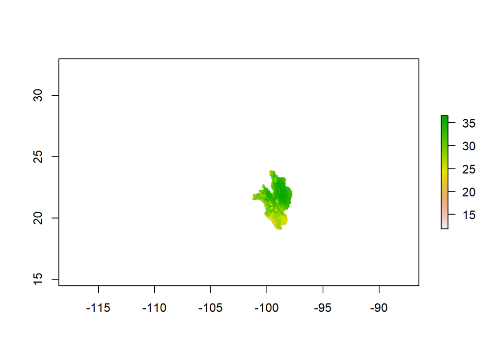

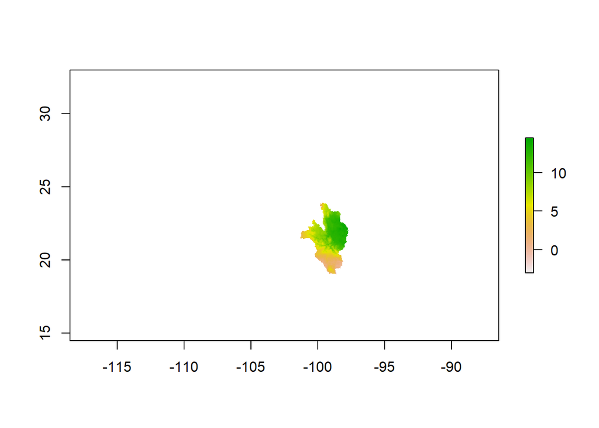

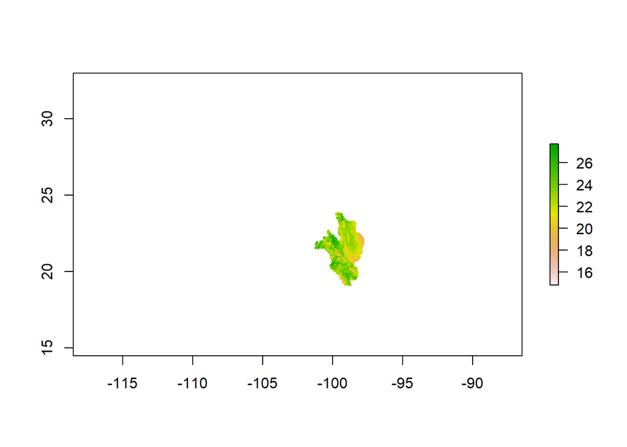

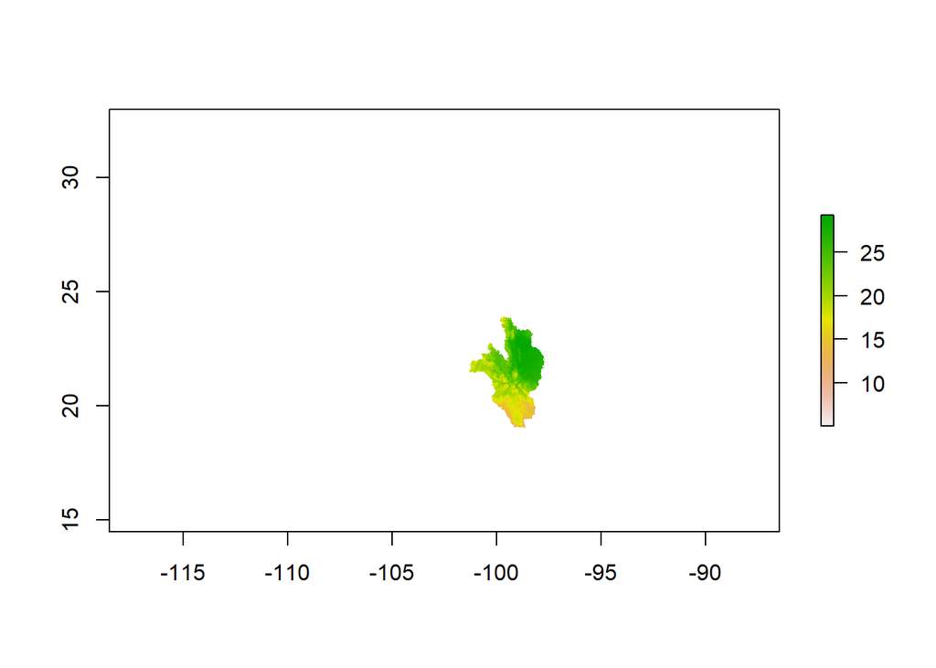

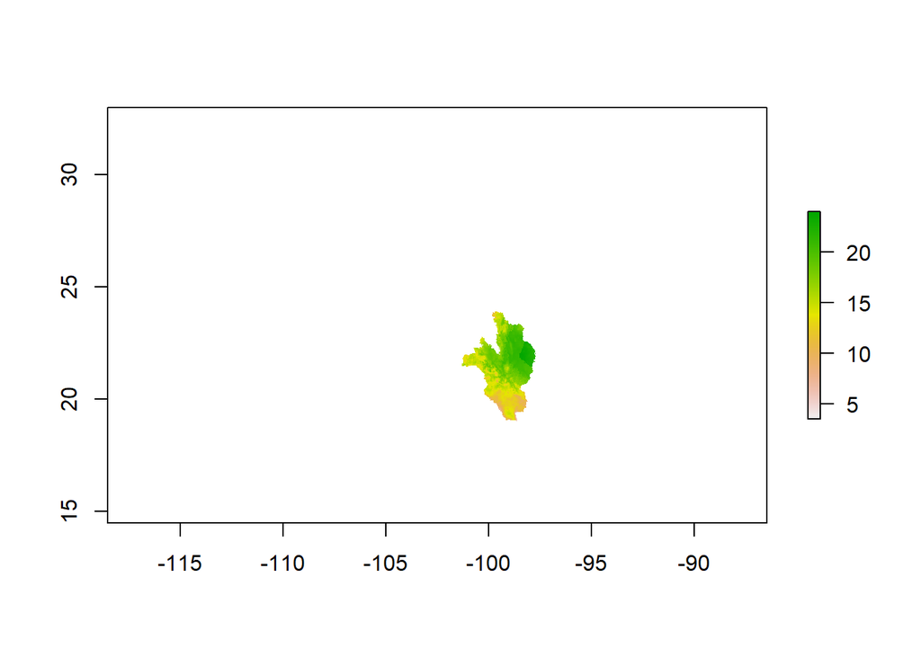

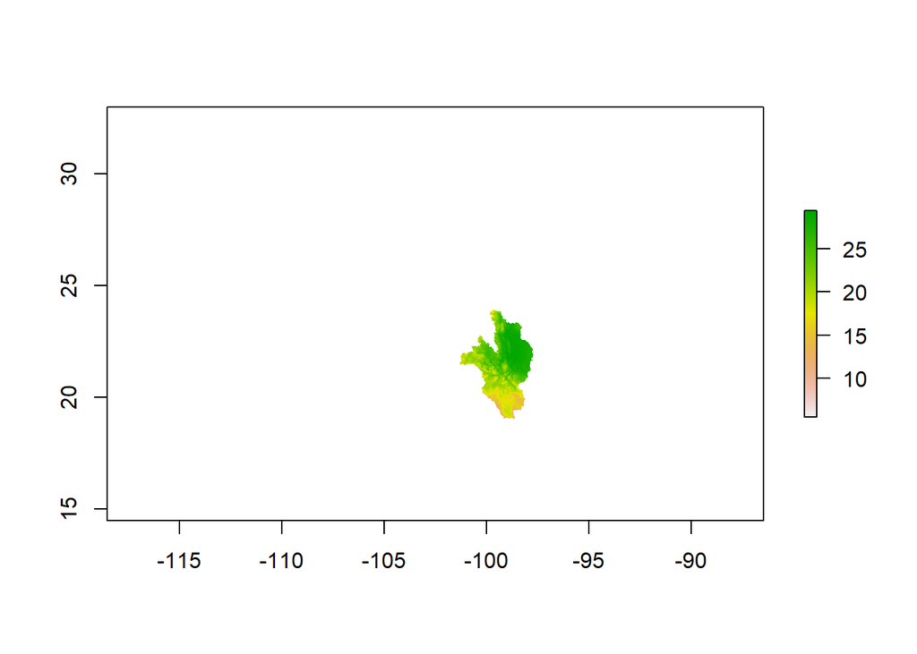

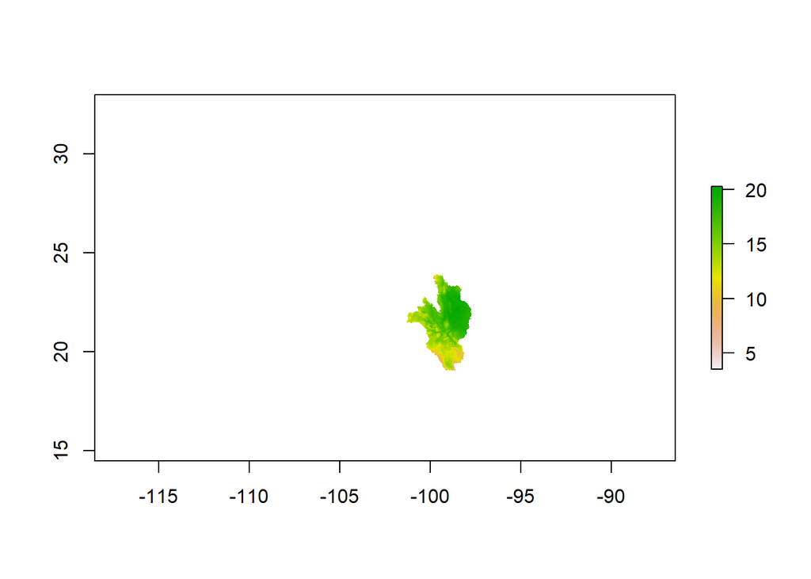

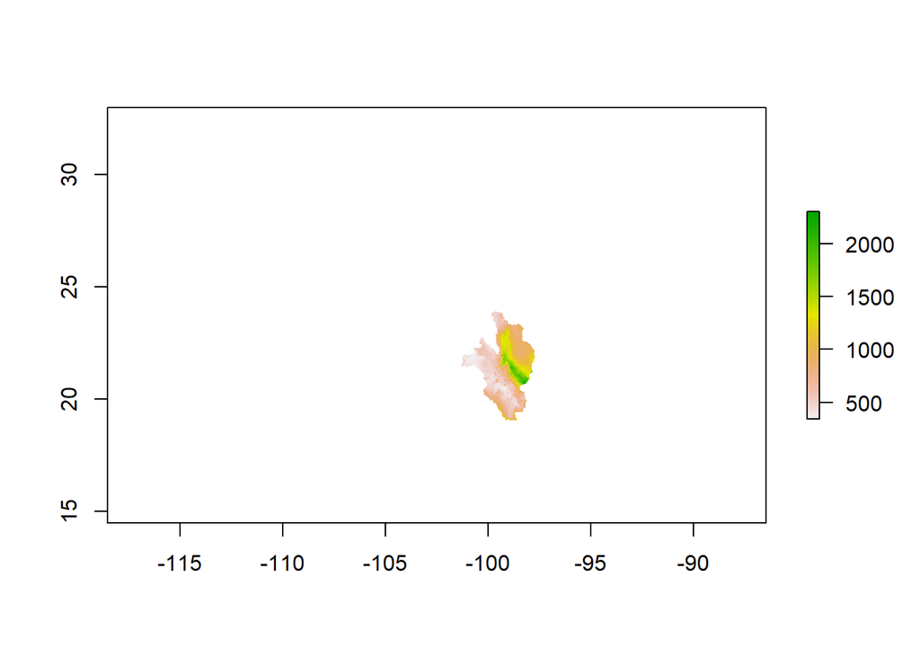

[7 more figures not shown]

```r
Bioclimexp<-c(BIO1 = "Annual Mean Temperature",
              BIO2 = "Mean Diurnal Range (Mean of monthly (max temp - min temp))",
              BIO3 = "Isothermality (BIO2/BIO7) (×100)",
              BIO4 = "Temperature Seasonality (standard deviation ×100)",
              BIO5 = "Max Temperature of Warmest Month",
              BIO6 = "Min Temperature of Coldest Month",
              BIO7 = "Temperature Annual Range (BIO5-BIO6)",
              BIO8 = "Mean Temperature of Wettest Quarter",
              BIO9 = "Mean Temperature of Driest Quarter",
              BIO10 = "Mean Temperature of Warmest Quarter",
              BIO11 = "Mean Temperature of Coldest Quarter",
              BIO12 = "Annual Precipitation",
              BIO13 = "Precipitation of Wettest Month",
              BIO14 = "Precipitation of Driest Month",
              BIO15 = "Precipitation Seasonality (Coefficient of Variation)",
              BIO16 = "Precipitation of Wettest Quarter",
              BIO17 = "Precipitation of Driest Quarter",
              BIO18 = "Precipitation of Warmest Quarter",
              BIO19 = "Precipitation of Coldest Quarter")

for(i in 1:19){
  rastr<-raster(bioclimvar[[bioclimvar@ptr[["names"]][i]]])
  corteclim<-raster::crop(rastr, mascara)
  corteclim = raster::mask(rastr, mascara)
  plot(corteclim)
  writeRaster(corteclim, paste("BIO",i,".asc",sep=""), overwrite=TRUE)

  }
```

## 2.3 Remoción de capas climáticas no necesarias.

```r
pca_path <- list.files(".",pattern = "*.asc$",full.names = T)###crea el stack de las variables climaticas del presente
capas_presente<- stack(pca_path)
especies<-c("birchmanni", "continens", "cortezi", "malinche", "multilineatus", "neza", "nigrensis", "pygmaeus", "variatus")

for(i in 1:length(especies)){
especiecurrent<-as.character(especies[i])
especieinv<-paste(especies[i], "inv", sep = "")
frame<-data.frame(get(especiecurrent)$Especie, get(especiecurrent)$X, get(especiecurrent)$Y)
eval(call("<-", as.name(especieinv), frame))



presencias_clima <- data.frame(raster::extract(capas_presente,get(especieinv)[,2:3]))###extrae los valores climaticos para cada uno de los puntos de presencia
presencias_clima2 <-data.frame(get(especieinv),presencias_clima)
presencias_clima3 <- na.omit(presencias_clima2)## omite mis datos de presencia sin valores climaticos.
write.csv(presencias_clima3[,1:3], file = paste(get(especiecurrent)[1,1], ".csv", sep = "")) ### para guardar el archivo de puntos

if (nrow(get(especieinv)) < 5){
  next
}

#### Matriz de colinearidad y estimación del Factor de inflación de Varianza (VIF)
cormatriz <- cor(presencias_clima3[,4:ncol(presencias_clima3)])#Definir cu?les son las columnas con las variables para hacer la correlaci?n (de la 1 a la 19)
eval(call("<-", as.name(paste("cormatriz", especiecurrent, sep = "")), cormatriz))

vif(presencias_clima3[,4:ncol(presencias_clima3)])# Priemro vemos si hay alta colinearidad entre variables

no_corr <- vifstep(presencias_clima3[,4:ncol(presencias_clima3)], th=10) # th: es el valor de umbral deseado;Para ver cuáles fueron las variables que quedaron sin colinearidad
no_corr

capascons<-c(no_corr@results[["Variables"]])
paste(especiecurrent, "capascons", sep = "")

eval(call("<-", as.name(paste(especiecurrent, "capascons", sep = "")), capascons))

}

capasconscomp<-list(birchmannicapascons, cortezicapascons, malinchecapascons, multilineatuscapascons, nezacapascons, pygmaeuscapascons, variatuscapascons)
comparar <- table(unlist(lapply(capasconscomp, unique)))

compdf<-as.data.frame(sort(comparar, decreasing = TRUE))#vemos el número de veces que se repite cada variable climática
borrar <- which(compdf$Freq < 2)
compdf <- compdf[-borrar,]#y removemos las que tengan menos observaciones.
capascons<- c(compdf$Var1) #estas son las variables que conservaríamos
capascons
```

```
## [1] BIO7  BIO9  BIO15 BIO4  BIO18
## Levels: BIO7 BIO9 BIO15 BIO4 BIO18 BIO13 BIO16 BIO6
```

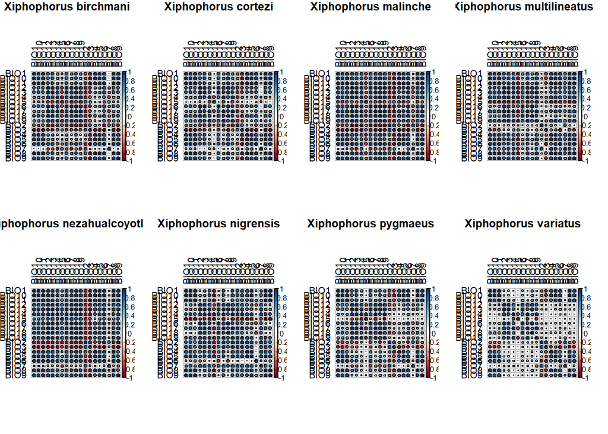

```r
par(mfrow=c(2,4))
corrplot(cormatrizbirchmanni, outline = TRUE, tl.col = "black", mar = c(2,0,1,1.5), title = "Xiphophorus birchmani")
corrplot(cormatrizcortezi, outline = TRUE, tl.col = "black", mar = c(2,0,1,1.5), title = "Xiphophorus cortezi")
corrplot(cormatrizmalinche, outline = TRUE, tl.col = "black", mar = c(2,0,1,1.5), title = "Xiphophorus malinche")
corrplot(cormatrizmultilineatus, outline = TRUE, tl.col = "black", mar = c(2,0,1,1.5), title = "Xiphophorus multilineatus")
corrplot(cormatrizneza, outline = TRUE, tl.col = "black", mar = c(2,0,1,1.5), title = "Xiphophorus nezahualcoyotl")
corrplot(cormatriznigrensis, outline = TRUE, tl.col = "black", mar = c(2,0,1,1.5), title = "Xiphophorus nigrensis")
corrplot(cormatrizpygmaeus, outline = TRUE, tl.col = "black", mar = c(2,0,1,1.5), title = "Xiphophorus pygmaeus")
corrplot(cormatrizvariatus, outline = TRUE, tl.col = "black", mar = c(2,0,1,1.5), title = "Xiphophorus variatus")
```

## 2.4 DEFINICIÓN DE ESPACIO AMBIENTAL (VARIABLES Y COORDENADAS)

```r
capasusar<-stack(paste(capascons[1:length(capascons)],".asc",sep=""))
resol <- res(capasusar)[1]
```

Generamos una tabla que para cada pixel (coordenada x, y) me diga el valor de todas las variables ambientales

```r
climpunto <- rasterToPoints(capasusar[[1]], fun=NULL, spatial=TRUE)
```

Extraemos datos ambientales para cada capa en capasusar de cada coordenada en climpunto

```r
clim <- raster::extract(capasusar, climpunto)
```

Damos formato a clim para que sea una tabla normal con dos primeras columnas X y Y

```r
clim <- data.frame(coordinates(climpunto),clim)
clim <- subset(clim, !is.na(colnames(clim)[3:ncol(clim)]))
```

Creamos los objetos para cada una de las especies

```r
occ.sp1 <- birchmanniinv[2:3]
occ.sp2 <- corteziinv[2:3]
occ.sp3 <- malincheinv[2:3]
occ.sp4 <- multilineatusinv[2:3]
occ.sp5 <- nezainv[2:3]
occ.sp6 <- nigrensisinv[2:3]
occ.sp7 <- pygmaeusinv[2:3]
occ.sp8 <- variatusinv[2:3]
```

### 2.4.1 Anadir variables climaticas a datos

```r
occ_sp1<-na.exclude(ecospat.sample.envar(dfsp=occ.sp1,colspxy=1:2, colspkept=1:2,dfvar=clim, colvarxy=1:2,colvar="all",resolution=0.008333))
occ_sp2<-na.exclude(ecospat.sample.envar(dfsp=occ.sp2,colspxy=1:2, colspkept=1:2,dfvar=clim, colvarxy=1:2,colvar="all",resolution=0.008333))
occ_sp3<-na.exclude(ecospat.sample.envar(dfsp=occ.sp3,colspxy=1:2, colspkept=1:2,dfvar=clim, colvarxy=1:2,colvar="all",resolution=0.008333))
occ_sp4<-na.exclude(ecospat.sample.envar(dfsp=occ.sp4,colspxy=1:2, colspkept=1:2,dfvar=clim, colvarxy=1:2,colvar="all",resolution=0.008333))
occ_sp5<-na.exclude(ecospat.sample.envar(dfsp=occ.sp5,colspxy=1:2, colspkept=1:2,dfvar=clim, colvarxy=1:2,colvar="all",resolution=0.008333))
occ_sp6<-na.exclude(ecospat.sample.envar(dfsp=occ.sp6,colspxy=1:2, colspkept=1:2,dfvar=clim, colvarxy=1:2,colvar="all",resolution=0.008333))
occ_sp7<-na.exclude(ecospat.sample.envar(dfsp=occ.sp7,colspxy=1:2, colspkept=1:2,dfvar=clim, colvarxy=1:2,colvar="all",resolution=0.008333))
occ_sp8<-na.exclude(ecospat.sample.envar(dfsp=occ.sp8,colspxy=1:2, colspkept=1:2,dfvar=clim, colvarxy=1:2,colvar="all",resolution=0.008333))
```

# 3 Calculo de una versión simplificada del modelo de nicho ecológico y comparaciones.

## 3.1 PCA-AMBIENTE

Estos valores serán más importantes para los tests de equivalencia y de similaridad

Se realiza un PCA para convertir los valores de las múltiples variables ambientales asociadas a cada ocurrencia en variables no correlacionadas que son más fáciles de manipular para los tests de equivalencia y similaridad.V

Vector de peso 0 para las ocurrencias y 1 para todos los sitios del area de estudio

```r
w<-c(rep(1,nrow(clim)),rep(0,nrow(occ_sp1)),rep(0,nrow(occ_sp2)), rep(0,nrow(occ_sp3)), rep(0,nrow(occ_sp4)),  rep(0,nrow(occ_sp5)),  rep(0,nrow(occ_sp6)),  rep(0,nrow(occ_sp7)), rep(0,nrow(occ_sp8))) # para las especies
```

El PCA se realiza con todos los datos del area de estudio Las presencias no son usadas para la calibracion del PCA pero sus coordenadas en los PCA son calculadas

```r
data<-rbind(clim[,3:ncol(clim)],occ_sp1[,3:ncol(occ_sp1)],occ_sp2[,3:ncol(occ_sp2)], occ_sp3[,3:ncol(occ_sp3)], occ_sp4[,3:ncol(occ_sp4)], occ_sp5[,3:ncol(occ_sp5)], occ_sp6[,3:ncol(occ_sp6)], occ_sp7[,3:ncol(occ_sp7)], occ_sp8[,3:ncol(occ_sp8)]) # para las especies
data <- subset(data, !is.na(colnames(clim)[3:ncol(clim)]))
pca.cal <-dudi.pca(data, row.w = w, center = T, scale = T, scannf = F, nf = 2)
pca.cal
```

```
## Duality diagramm
## class: pca dudi
## $call: dudi.pca(df = data, row.w = w, center = T, scale = T, scannf = F,
##     nf = 2)
##
## $nf: 2 axis-components saved
## $rank: 5
## eigen values: 307900 134000 122500 39820 9970
##   vector length mode    content
## 1 $cw    5      numeric column weights
## 2 $lw    122974 numeric row weights
## 3 $eig   5      numeric eigen values
##
##   data.frame nrow   ncol content
## 1 $tab       122974 5    modified array
## 2 $li        122974 2    row coordinates
## 3 $l1        122974 2    row normed scores
## 4 $co        5      2    column coordinates
## 5 $c1        5      2    column normed scores
## other elements: cent norm
```

Filas en que estan los datos de clim y de cada una de las especies:

```r
row.clim <- 1:nrow(clim)
row.sp1 <- (1+nrow(clim)):(nrow(clim) + nrow(occ_sp1))
row.sp2 <- (1 + nrow(clim) + nrow(occ_sp1)) : (nrow(clim) + nrow(occ_sp1) + nrow(occ_sp2))
row.sp3 <- (1 + nrow(clim) + nrow(occ_sp1) + nrow(occ_sp2)) : (nrow(clim) + nrow(occ_sp1) + nrow(occ_sp2) + nrow(occ_sp3))
row.sp4 <- (1 + nrow(clim) + nrow(occ_sp1) + nrow(occ_sp2) + nrow(occ_sp3)) : (nrow(clim) + nrow(occ_sp1) + nrow(occ_sp2) + nrow(occ_sp3) + nrow(occ_sp4))
row.sp5 <- (1 + nrow(clim) + nrow(occ_sp1) + nrow(occ_sp2) + nrow(occ_sp3) + nrow(occ_sp4)) : (nrow(clim) + nrow(occ_sp1) + nrow(occ_sp2) + nrow(occ_sp3) + nrow(occ_sp4) + nrow(occ_sp5))
row.sp6 <- (1 + nrow(clim) + nrow(occ_sp1) + nrow(occ_sp2) + nrow(occ_sp3) + nrow(occ_sp4) + nrow(occ_sp5)) : (nrow(clim) + nrow(occ_sp1) + nrow(occ_sp2) + nrow(occ_sp3) + nrow(occ_sp4) + nrow(occ_sp5) + nrow(occ_sp6))
row.sp7 <- (1 + nrow(clim) + nrow(occ_sp1) + nrow(occ_sp2) + nrow(occ_sp3) + nrow(occ_sp4) + nrow(occ_sp5) + nrow(occ_sp6)) : (nrow(clim) + nrow(occ_sp1) + nrow(occ_sp2) + nrow(occ_sp3) + nrow(occ_sp4) + nrow(occ_sp5) + nrow(occ_sp6) + nrow(occ_sp7))
row.sp8 <- (1 + nrow(clim) + nrow(occ_sp1) + nrow(occ_sp2) + nrow(occ_sp3) + nrow(occ_sp4) + nrow(occ_sp5) + nrow(occ_sp6) +  nrow(occ_sp7)) : (nrow(clim) + nrow(occ_sp1) + nrow(occ_sp2) + nrow(occ_sp3) + nrow(occ_sp4) + nrow(occ_sp5) + nrow(occ_sp6) + nrow(occ_sp7) +  nrow(occ_sp8))
```

Las coordenadas en cada uno de los ejes del PCA para los datos de toda el area de estudio y de cada una de las especies

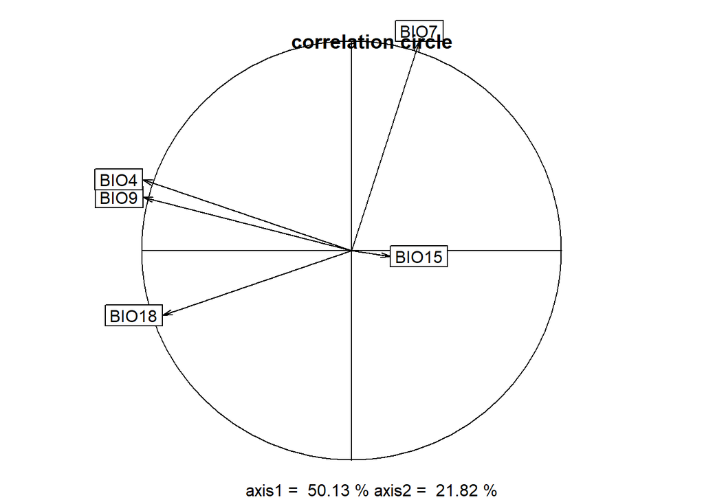

```r
scores.clim <- pca.cal$li[row.clim,] #coordenadas para todas las celdas
scores.sp1  <- pca.cal$li[row.sp1,]   #coordenadas para sp1
scores.sp2  <- pca.cal$li[row.sp2,]   #coordenadas para sp2
scores.sp3  <- pca.cal$li[row.sp3,]   #coordenadas para sp3
scores.sp4  <- pca.cal$li[row.sp4,]   #coordenadas para sp4
scores.sp5  <- pca.cal$li[row.sp5,]   #coordenadas para sp5
scores.sp6  <- pca.cal$li[row.sp6,]   #coordenadas para sp6
scores.sp7  <- pca.cal$li[row.sp7,]   #coordenadas para sp7
scores.sp8  <- pca.cal$li[row.sp8,]   #coordenadas para sp8

ecospat.plot.contrib(contrib=pca.cal$co, eigen=pca.cal$eig)
```